# Reproducible Research: Peer Assessment 1

Christophe Guerrier

17 October 2014

## Loading and preprocessing the data

1. Load the data (i.e. read.csv())

First we unzip the data, and load it with read.csv.

```r
unzip(zipfile = "./activity.zip")
activity = read.csv(file = "./activity.csv",header=TRUE)
```

2. Process/transform the data (if necessary) into a format suitable for your analysis

Loading **dplyr** library to make data munging easier.

```r
library(dplyr)
```

Now converting date, and compute time from intervas.

```r
activity$day = as.Date(activity$date,format = "%Y-%m-%d")
activity$hour = floor(activity$interval/100)
activity$min = 100 *(activity$interval /100 - floor(activity$interval/100))
activity$time = as.POSIXct(x = paste(activity$date,activity$hour,activity$min),format = "%Y-%m-%d %H %M")
```

Compute the number of steps for each day.

```r
per_day   <- aggregate(steps ~ date, data= activity, FUN=sum)
```

Compute the average daily number of steps by 5 minute interval time.

```r
per_interval <- aggregate(steps ~ interval, data= activity, FUN=mean)
```

## What is mean total number of steps taken per day?

For this part of the assignment, you can ignore the missing values in the dataset.

1. Histogram of the total number of steps taken each day.

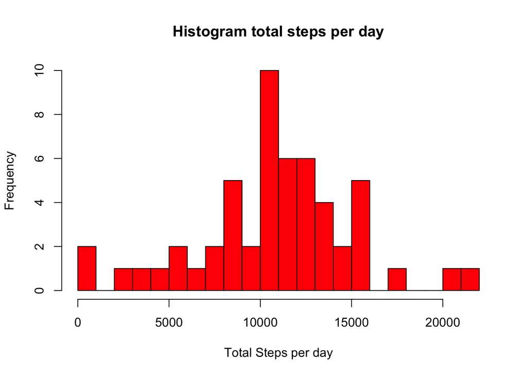

```r
hist(per_day$steps, breaks=30, main="Histogram total steps per day",
     xlab ="Total Steps per day", col = 'red')
```

2. Computing the mean and the median total number of steps taken per day:

```r
meapds <- mean(per_day$steps)
medpds <- median(per_day$steps)
```

The mean steps per day is 1.0766 × 10<sup>4</sup> and the median is 10765.

## What is the average daily activity pattern?

1. Looking at daily activity.

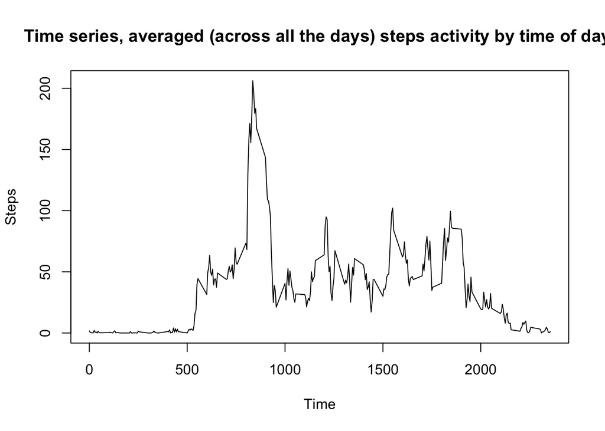

```r
plot(per_interval, type = 'l',
     main = "Time series, averaged (across all the days) steps activity by time of day.", ylab = "Steps", xlab="Time")
```

The step activity spikes aournd 9AM, let’s calculate the interval.

2. Which 5-minute interval, on average across all the days in the dataset, contains the maximum number of steps?

```r
per_interval[which.max(per_interval$steps),"interval"]
```

```
## [1] 835
```

So the maximum is reached ( in average accross all days) at **8:35AM**.

## Imputing missing values

We are now looking at missing values in our datasets.

Calculate and report the total number of missing values in the dataset (i.e. the total number of rows with NAs) 1. Missing Values

```r
indexNA <- which(is.na.data.frame(activity),arr.ind = TRUE)
nacount <- nrow(indexNA)
```

There is **2304** NA values.

2. Filling the NAs.

```r
#duplicate
activityNoNa <- activity
```

Fill with median per day, divided by number of interval since the row are intervals.

```r
activityNoNa[indexNA] <- medpds/288
```

Sanity check for the NA, did we remove all of them ?

```r
sum(is.na.data.frame(activityNoNa)) == 0
```

```
## [1] TRUE
```

3. Histogram

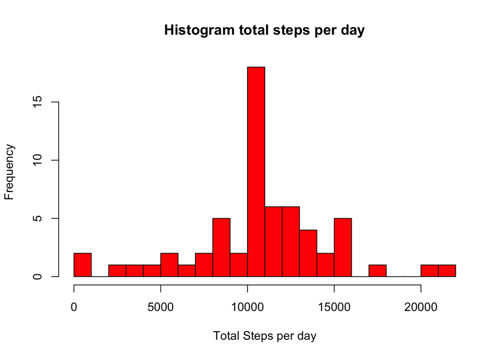

```r
per_dayNoNA   <- aggregate(steps ~ date, data= activityNoNa, FUN=sum)
hist(per_dayNoNA$steps, breaks=30, main="Histogram total steps per day",
     xlab ="Total Steps per day", col = 'red')
```

Re Computing the mean and the median total number of steps taken per day:

```r
meapnonads <- mean(per_dayNoNA$steps)
medpnonads <- median(per_dayNoNA$steps)
```

The mean steps per day is 1.0766 × 10<sup>4</sup> and the median is 1.0765 × 10<sup>4</sup>.

Let’s compare what the NA filling did to the mean, and median, first by overlaying the 2 histograms.

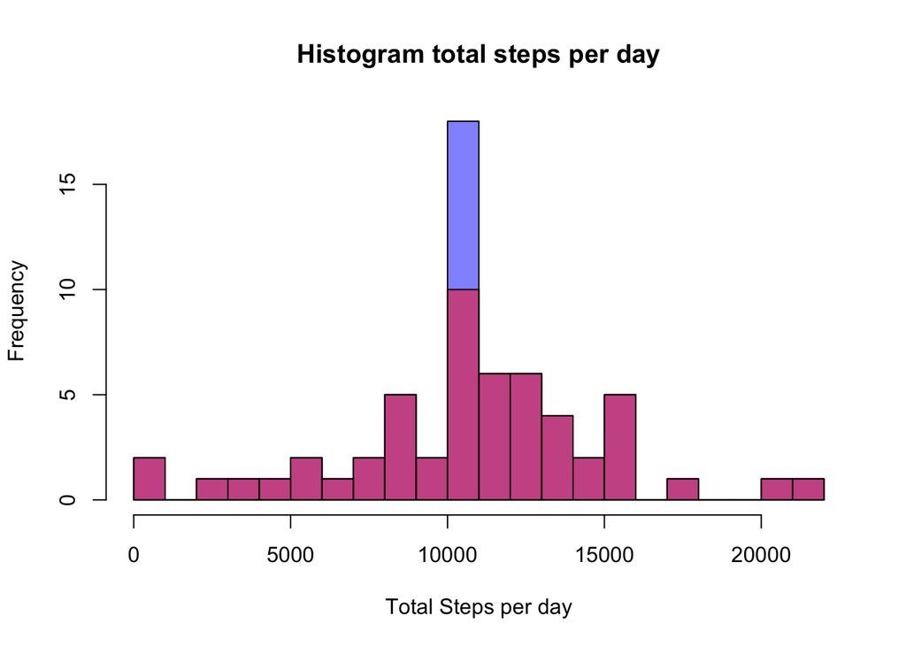

```r
hist(per_dayNoNA$steps, breaks=30, main="Histogram total steps per day",
     xlab ="Total Steps per day", col = rgb(0,0,1,0.5))
hist(per_day$steps, breaks=30, col = rgb(1,0,0,0.5), add=T)
```

Did the mean change ?

```r
meapnonads - meapds != 0
```

```
## [1] TRUE
```

```r
meapnonads - meapds
```

```
## [1] -0.1559
```

Did the median stayed the same ?

```r
medpnonads - medpds == 0
```

```
## [1] TRUE
```

```r
medpnonads - medpds
```

```
## [1] 0
```

Since we added 2304 using the median, the histogram median bar increased, but the mean and median previously only slighlty changed. A better way to fill the NA could be to identify the day/interval were the missing data and replace with a value more inline with the average of that day.

If we look at when the missing data happens.

```r
table(weekdays(activity[indexNA[,1],"time"]))
```

```
##
##    Friday    Monday  Saturday    Sunday  Thursday Wednesday
##       576       576       288       288       288       288
```

It for example never happen on Tuesdays.

## Are there differences in activity patterns between weekdays and weekends?

1. New variable (factor)

```r
activity$weekend <- weekdays(activity$time)== "Saturday"
activity$weekend <- weekdays(activity$time)== "Sunday"
activity$weekdays <- factor(activity$weekend , levels = c("weekday","weekend"))
activity[which(activity$weekend),]$weekdays <- "weekend"
activity[-which(activity$weekend),]$weekdays <- "weekday"

per_intervalW <- aggregate(steps ~ interval + weekdays, data= activity, FUN=mean)
```

2. Panel plot

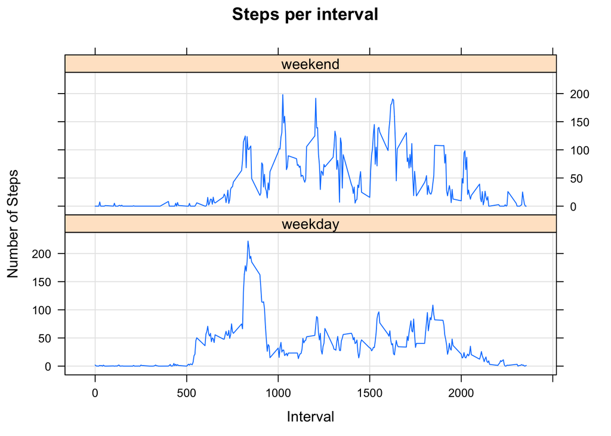

```r
library(lattice)
xyplot(steps ~ interval|weekdays ,data = per_intervalW, type='l',grid=TRUE,
    main="Steps per interval", layout = c(1,2),
   ylab="Number of Steps", xlab="Interval")
```